# 경제자료분석과 예측 - #04 시계열 변환

2025년 2학기

## 시계열의 구성요소 분해

## 시계열 자료의 특성

- 시계열 자료(time series data)는 다양한 패턴을 보일 수 있으며,  
  각 패턴 유형을 나타내는 여러 구성요소로 분리하면 분석에 도움이 된다.
- 지난 수업에서는 시계열 패턴의 세 가지 유형을 논의했다:  
  **추세(trend)**, **계절성(seasonality)**, 그리고 **순환(cycles)**.
- 시계열을 구성요소로 분해할 때는 일반적으로  
  추세(trend)와 순환(cycle)을 하나의 **추세-순환(trend-cycle)** 구성요소로 통합한다.  
  (간단히 “추세(trend)”라고 부르기도 한다.)

## 시계열 자료의 구성요소

- 따라서 시계열은 다음의 세 가지 구성요소로 생각할 수 있다:
  1. **추세-순환(trend-cycle)** 구성요소
  2. **계절성(seasonal)** 구성요소
  3. **잔차(remainder)** 구성요소 — 시계열의 나머지 변동 요인을 포함
- 일부 시계열(예: 일 단위 이상으로 관측된 자료)의 경우,  
  서로 다른 주기(period)를 갖는 **복수의 계절성** 구성요소가 존재할 수 있다.

## 수업 목표

- 이 장에서는 시계열에서 이러한 구성요소를 추출하는 대표적인 방법을 다룬다.  
  이러한 분해는 시계열에 대한 이해를 높이는 데 도움이 될 뿐 아니라,  
  **예측 정확도를 향상**시키는 데에도 유용하다.
- 시계열을 분해하기 전에, 분석을 더 단순하게 만들기 위해  
  시계열을 **변환(transform)** 하거나 **조정(adjust)** 하는 것이 유용할 수 있다.  
  따라서 본 장에서는 변환과 조정에 대한 논의로부터 시작한다.

## 변수 변환

## 변수 변환과 적응(adjustment)

- **목적:**  
  과거 자료의 알려진 변동 요인을 제거하거나, 전 구간에서 변동 패턴을 더 일관되게 만들어 **모형화와 예측을 단순화/정확화**한다.
- **범주:**
  1. 달력(Calendar) 조정
  2. 인구(Population) 조정
  3. 물가(인플레이션) 조정
  4. 수학적 변환(Mathematical transformation)

## 달력(Calendar) 조정

- 월별/분기별 총합에는 **영업일 수 차이 등 달력 효과**가 섞인다.  
  → 예: **월 매출 총액 대신 영업일당 평균 매출**을 사용하면 달력 변동을 제거할 수 있다.

## 인구(Population) 조정

- **인구 규모 변화**로 인해 총량 비교가 왜곡될 수 있다.  
  → **1인당(또는 천/백만 인당) 값**으로 바꾸면 총량 증가에도 불구하고 **실질적인 변화(감소 등)**를 해석할 수 있다.  
  → 예: `global_economy` 데이터의 **GDP per capita** 사용.

## 인구(Population) 조정전

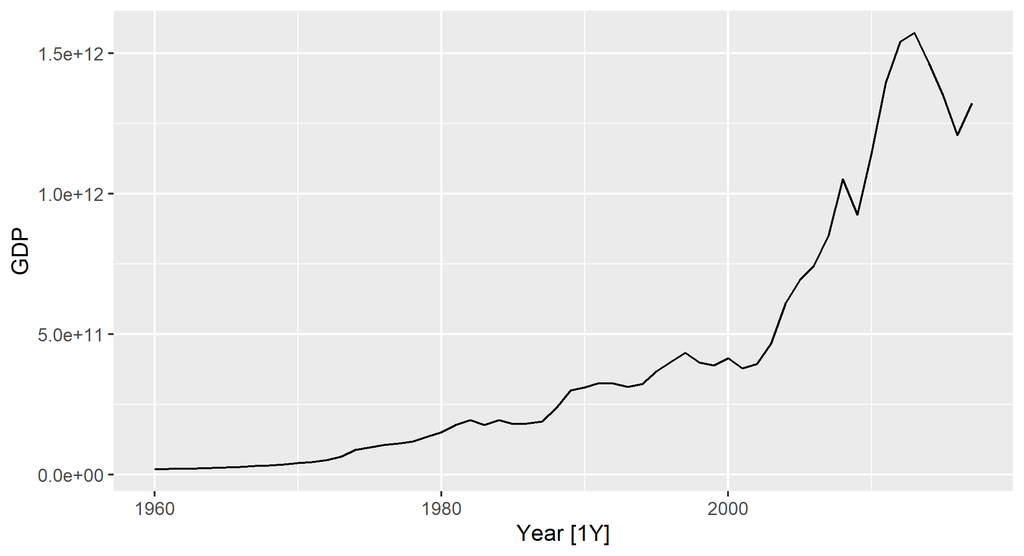

```r
global_economy |>
  filter(Country == "Australia") |>
  autoplot(GDP)
```

## 인구(Population) 조정후

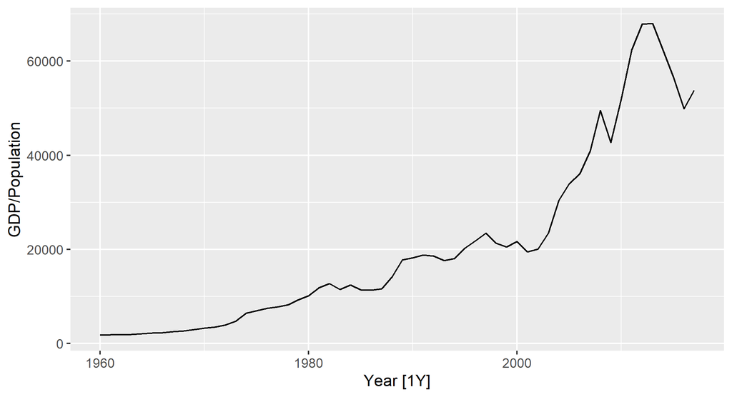

```r
global_economy |>
  filter(Country == "Australia") |>
  autoplot(GDP / Population)
```

## 물가(인플레이션) 조정

- **화폐 가치 변화**로 인해 시계열의 명목적 변화와 실질적 변화가 뒤섞일 수 있다. → **가격지수(예: CPI)** 를 사용하여 기준연도의 실질 화폐 단위로 환산한다.
- **조정식:**  
  \[ x_t = \frac{y_t}{z_t} \times z_{2000} \]  
  (여기서 \(y_t\): 원시계열, \(z_t\): 가격지수, \(x_t\): 물가조정된 시계열)
- **효과:**  
  물가 조정 후에는 **실질 추세(real trend)** 가 드러나며, 명목 데이터와 다른 해석이 가능하다.
- 명목변수를 인플레이션 조정을 통해서 실질변수화

## 물가(인플레이션) 조정

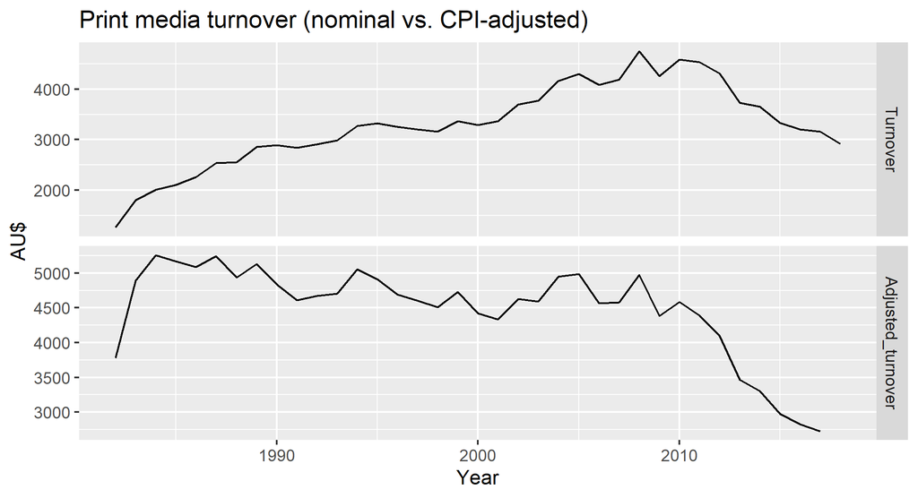

## 수학적 변환(Mathematical Transformations)

- **목적:**  
  시계열의 변동폭이 수준에 따라 달라지는 **분산 비정상성(heteroscedasticity)** 을 완화하고, **모형 단순화 및 예측 안정성**을 높인다.
- 시계열에서 값의 **수준(level)** 이 커질수록 **변동성(분산)** 도 커지는 패턴(이분산성)이 보이면, **변환**이 유용하다.
- 원자료를 \(y_1,\dots,y_T\), 변환 후 자료를 \(w_1,\dots,w_T\)라 두자.

## 로그(Log) 변환

- 식:  
  \[ w_t = \log(y_t) \]
- **특징:**
  - 변동의 상대적 크기(%)를 일정하게 만들어준다.
  - 로그 차이 ≈ **비율(%) 변화율**로 해석 가능.
  - 단, \(y_t \le 0\) 인 경우에는 적용 불가.

## 거듭제곱(Power) 변환

- 식:  
  \[ w_t = y_t^p \]
- **특징:**
  - \(p < 1\)일 때 큰 값의 영향을 줄이며 분산을 안정화한다.
  - 로그 변환보다 직관성은 떨어지지만, **음수 값 처리에는 유연**하다.

| 변환 | 수식 |
| --- | --- |
| 제곱근 | \(w_t=\sqrt{y_t}\) |
| 세제곱근 | \(w_t=\sqrt[3]{y_t}\) |
| 로그 | \(w_t=\log(y_t)\) |

## 왜 로그가 해석에 유리한가?

- **효과 강도(약 → 강)**: 제곱근 < 세제곱근 < 로그
- 경험 법칙
  - \(\operatorname{Var}(y_t)\propto \mathbb{E}(y_t)\) (대략 포아송형) → \(\sqrt{y_t}\)가 안정화에 유리
  - \(\operatorname{Var}(y_t)\propto \mathbb{E}(y_t)^2\) (승수적 오차) → \(\log y_t\)가 유리
- 승수적 잡음 모형 \(y_t=\mu_t\exp(\varepsilon_t)\)이면 \[ \log y_t=\log \mu_t+\varepsilon_t, \] 즉 **가산형**으로 단순화되어 선형 모형 적용이 쉬워진다.
- 로그 변화는 **상대(%) 변화**다: \[ \Delta \log y_t \approx \frac{y_t-y_{t-1}}{y_{t-1}}\ (\text{비율 변화}). \]

## Box–Cox 변환

- 식:  
  \[ w_t = \begin{cases} \log(y_t), & \lambda = 0 \\ \dfrac{\mathrm{sign}(y_t)\,|y_t|^\lambda - 1}{\lambda}, & \lambda \ne 0 \end{cases} \]
- **특징:**
  - \(\lambda = 0\): 로그 변환과 동일
  - \(\lambda = 1\): 원자료 그대로
  - \(\lambda > 0\): **음수 값 포함 가능(수정형)**
  - 목적: **분산 안정화 및 비선형 관계 완화**

## \(\lambda\) 선택 – Guerrero 방법

- **Guerrero(1993)** 방법을 사용하면, 계절 변동의 상대적 크기를 일정하게 만드는  
  최적의 \(\lambda\)를 자동으로 선택할 수 있다.
- 계절 변동의 상대적 크기를 일정하게 만드는 \(\lambda\) 실무적으로 유리.
- `features(..., guerrero)`로 자동 선택 가능(예: 가스 생산자료에 \(\lambda \approx 0.1\)

## \(\lambda\) 선택 – Guerrero 방법

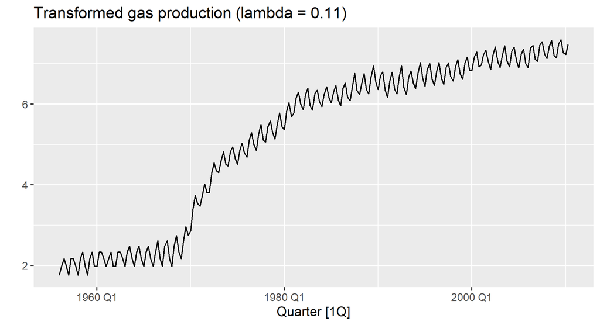

## 이론 요약

- 목적: **분산 안정화**, **선형화**, **승수형 → 가산형** 변환(log/Box–Cox).
- Box–Cox 변환: \(y_t^{(\lambda)} = \begin{cases}\dfrac{y_t^{\lambda}-1}{\lambda}, & \lambda\ne0\\ \log(y_t), & \lambda=0\end{cases}\) (양의 \(y_t\)에서 정의).
- 승수형 계절·이분산이 강할 때 **로그 변환**이 간단하고 해석(%)이 용이.
- 로그 스케일 예측의 역변환 시 **편의(Bias) 보정**: \(\mathrm{E}[\exp(X)] = \exp(\mu+\sigma^2/2)\).

## 역변환과 바이어스 보정

- 로그 스케일에서 예측(또는 잔차 분산 \(s^2\))이 있다면, 원스케일 기대값 보정: \[ \mathbb{E}(Y)\approx \exp(m+s^2/2)\quad(\text{Jensen 보정}). \]
- Box–Cox의 역변환은 \(\lambda\neq 0\)에서 \(y_t=(\lambda w_t+1)^{1/\lambda}\).  
  로그 외 변환에서도 **Duan의 smearing** 등 경험적 보정을 고려할 수 있다.

## 예시

```r
# 모의 데이터: 수준↑ → 분산↑ (승수적 오차)
set.seed(1)
t  <- 1:200
mu <- exp(0.01*t)           # 완만한 성장 추세
y  <- mu * exp(rnorm(200, 0, 0.2))
# 변환
y_sqrt <- sqrt(y)
y_log  <- log(y)
# 전반부/후반부 표준편차 비교로 분산 안정화 확인
seg <- rep(c("H1","H2"), each = 100)
sd_raw  <- tapply(y,      seg, sd)
sd_sqrt <- tapply(y_sqrt, seg, sd)
sd_log  <- tapply(y_log,  seg, sd)
rbind(Raw=sd_raw, Sqrt=sd_sqrt, Log=sd_log)
```

```
##             H1        H2
## Raw  0.6124107 1.7396191
## Sqrt 0.2241479 0.3856238
## Log  0.3389964 0.3515800
```

## 예제: 호주 식품소매업 : 다양한 변환 방법

```r
food <- aus_retail |>
  filter(Industry == "Food retailing") |>
  summarise(Turnover = sum(Turnover))
```

## 예제: 호주 식품소매업 : 다양한 변환 방법

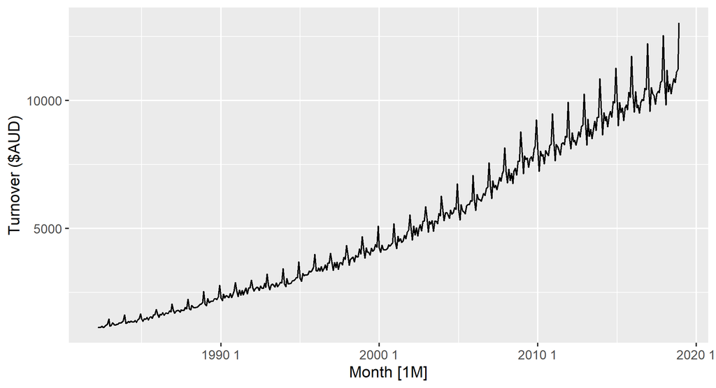

```r
food |> autoplot(Turnover) +
  labs(y = "Turnover ($AUD)")
```

## 예제: 호주 식품소매업 : 다양한 변환 방법

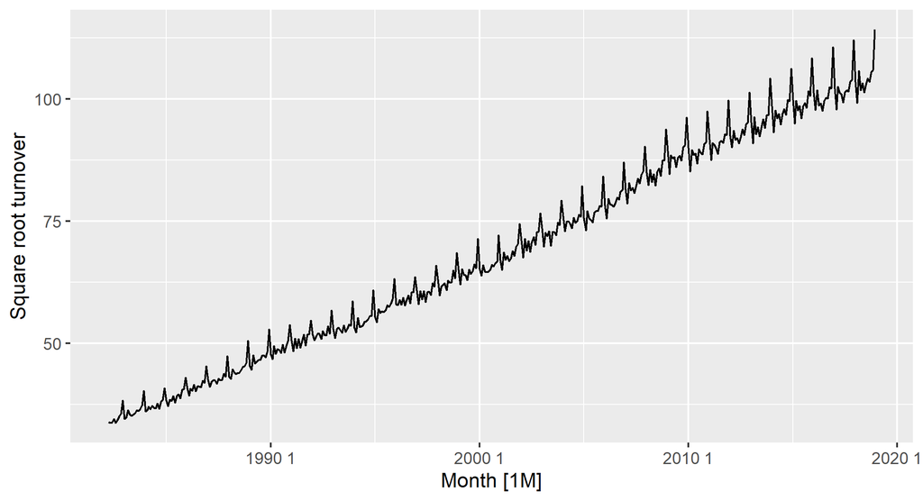

```r
food |> autoplot(sqrt(Turnover)) +
  labs(y = "Square root turnover")
```

## 예제: 호주 식품소매업 : 다양한 변환 방법

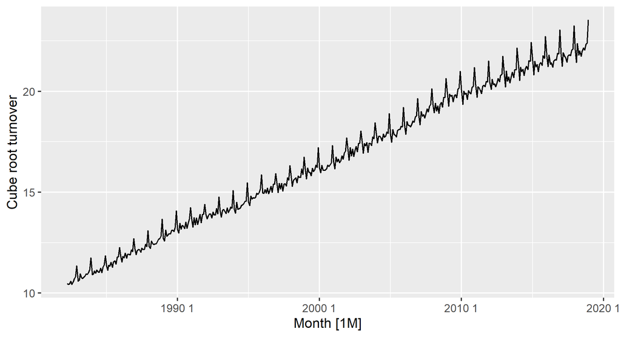

```r
food |> autoplot(Turnover^(1 / 3)) +
  labs(y = "Cube root turnover")
```

## 예제: 호주 식품소매업 : 다양한 변환 방법

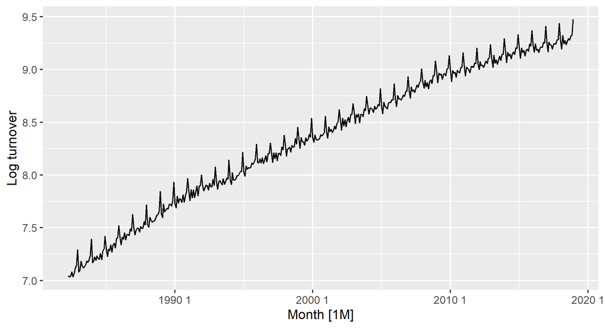

```r
food |> autoplot(log(Turnover)) +
  labs(y = "Log turnover")
```

## 예제: 호주 식품소매업 : 다양한 변환 방법

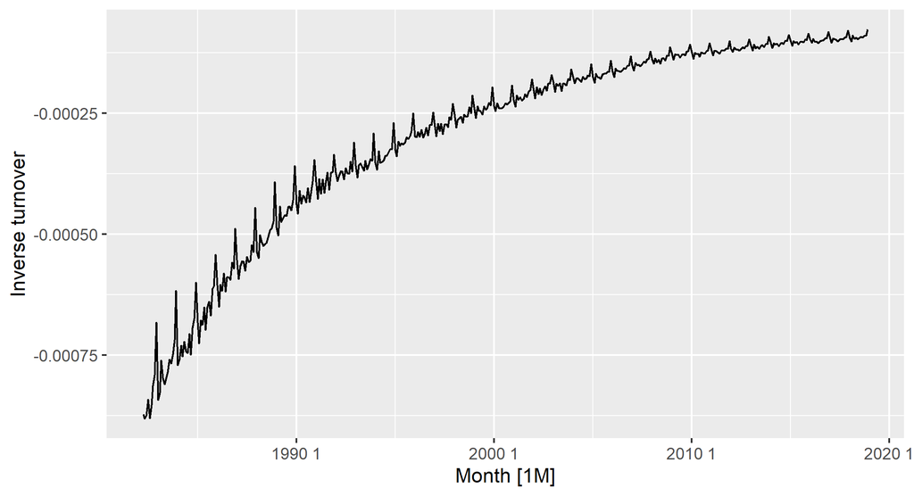

```r
food |> autoplot(-1 / Turnover) +
  labs(y = "Inverse turnover")
```

## Box–Cox 변환 응용

- 수준(값의 크기)에 따라 변동성이 달라지는(이분산) 시계열에서는 **변환**이 유용하다.
- 표준적인 Box–Cox 변환(양의 자료)은 \[ w_t= \begin{cases} \dfrac{y_t^\lambda-1}{\lambda}, & \lambda\neq 0,\\[6pt] \log(y_t), & \lambda=0, \end{cases} \qquad (y_t>0) \] 이다.

## Box–Cox 변환 응용

- 음수 혹은 0을 포함한 자료에는 **Bickel–Doksum(부호 포함) 변환**이나 **Yeo–Johnson** 같은 대안을 고려할 수 있는데, Bickel–Doksum 형태는 \[ w_t= \begin{cases} \dfrac{\operatorname{sign}(y_t)\,\lvert y_t\rvert^\lambda - 1}{\lambda}, & \lambda\neq 0,\\[6pt] \operatorname{sign}(y_t)\,\log\!\lvert y_t\rvert, & \lambda=0, \end{cases} \]
- \(\lambda=1\): 의미 있는 변환 없음(원자료)
- \(\lambda=\tfrac12\): 제곱근 변환(선형 이동 포함)
- \(\lambda=0\): 자연로그 변환
- \(\lambda=-1\): 역수 계열(선형 이동 포함)

## **소결**

- 로그 변환은 승수적 잡음 \(y_t=\mu_t\exp(\varepsilon_t)\)을 \(\log y_t=\log\mu_t+\varepsilon_t\)처럼 **가산형**으로 바꿔 선형모형 적용을 쉽게 한다
- \(\Delta\log y_t \approx (y_t-y_{t-1})/y_{t-1}\)이므로 **상대(%) 변화**로 해석하기 좋다.

## (추가) 몇 가지 람다를 고정해 변환 후 선을 비교

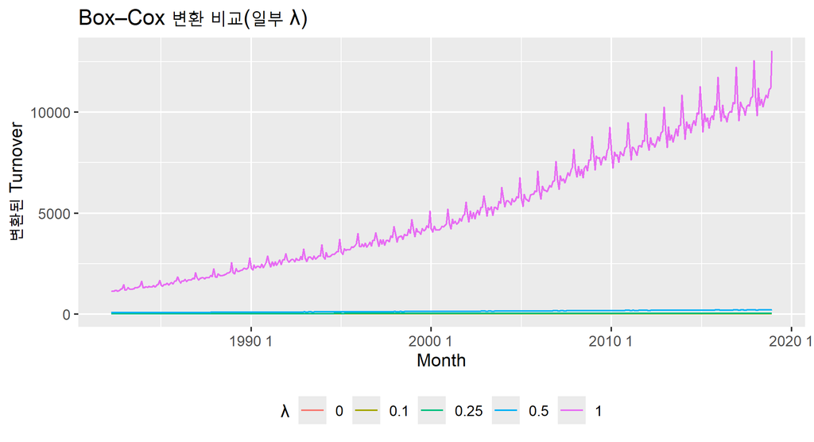

## 시계열 구성요소

## 개요

- 시계열은 보통 다음 **세 가지 구성요소**로 분해하여 해석한다.
  1. **추세-순환(Trend-cycle,** \(T_t\)): 장기적 상승/하락 및 경기적 순환
  2. **계절성(Seasonality,** \(S_t\)): 일정 주기마다 반복되는 패턴
  3. **잔차(Remainder,** \(R_t\)): 위 두 요소를 제외한 불규칙 변동(오차)

## 가법(additive) vs 승법(multiplicative) 구조

- **가법 모형**: 수준(level)과 무관하게 변동폭이 거의 일정할 때 적합  
  \[ y_t = T_t + S_t + R_t \]
- **승법 모형**: 수준이 높을수록 변동폭(계절·잡음)이 커질 때 적합  
  \[ y_t = T_t \times S_t \times R_t \]

**선택 기준 요약**

- **가법**: 계절 변동 폭이 수준(level)에 따라 크게 변하지 않을 때
- **승법**: 시계열의 수준이 높을수록 계절 변동 폭도 커질 때 (예: 경제 시계열)

## 로그 변환과의 관계

- 승법 구조에 **로그 변환**을 적용하면 가법 구조로 변환된다. \[ \log y_t \;=\; \log T_t \;+\; \log S_t \;+\; \log R_t \]
- 실무 팁: 승법이 의심되면 **로그 변환 후 가법 분해**를 시도  
  (분산 안정화, 해석 용이성 증가)

## 계절 조정

- **정의**: 시계열에서 **계절 성분** \(S_t\) 을 제거한 것
  - 가법: \[ y_t^{(sa)} = y_t - S_t \]
  - 승법: \[ y_t^{(sa)} = \frac{y_t}{S_t} \]
- **해석**: \(y_t^{(sa)}\)는 대체로 **추세-순환 + 잔차**만 남음  
  → 경기 동향 파악, 전환점(턴포인트) 탐지에 유용  
  → 단, **매끄러운 흐름**을 보려면 계절조정 값 자체보다 \(T_t\) (추세-순환) 활용이 더 적절

## 구성요소별 특징과 해석

- \(T_t\) (추세-순환): 장기 흐름과 경기 순환의 결합.
  - 장기 성장/하락, 전환점, 국면(확장/수축)을 해석할 때 핵심
- \(S_t\) (계절성): 주기적 반복.
  - 월·분기 효과, 요일/명절 효과 등
  - 시간 경과에 따라 **계절 패턴이 완만히 변형**될 수 있음
- \(R_t\) (잔차): 설명 불가한 단기 변동·이상치 포함.
  - 모형 적합성 진단(독립성, 분산, 정규성)에서 중요한 단서

## 실무 팁

- **분해 구조 선택**:
  - 레벨에 따라 계절 진폭이 달라지면 승법 또는 **로그+가법**
  - 그렇지 않으면 가법
- **변환 전후 비교**:
  - 변환(로그/Box–Cox) 적용 전후로 **계절 진폭·잔차 분산**이 안정되는지 확인
- **계절 조정 vs 추세-순환**:
  - 단기 비교(환경·정책 영향 등)는 계절조정 값 유용
  - 경기 국면/전환점 분석은 \(T_t\) 활용
- **보고/커뮤니케이션**:
  - 원시계열과 함께 **분해 결과(추세·계절·잔차, 계절조정)** 를 병기하면 해석 투명성↑

## 이동평균 (Moving Averages)

## 개요

- 고전적 시계열 분해 방식은 1920년대부터 시작되어 1950년대까지 널리 쓰였다.
- 이 방식의 첫 단계는 **이동평균(moving average)** 을 사용하여 추세-순환(trend-cycle)을 추정하는 것이다.

## 호주의 수출 데이터 예제

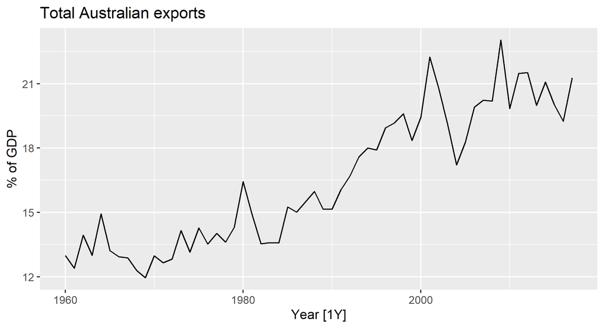

```r
global_economy |>
  filter(Country == "Australia") |>
  autoplot(Exports) +
  labs(y = "% of GDP", title = "Total Australian exports")
```

## 이동평균 평활

- **m차 이동평균 (m-MA)** 은 다음과 같이 정의된다:  
  \[ \hat{T}_t = \frac{1}{m} \sum_{j=-k}^{k} y_{t+j} \quad \text{여기서 } m = 2k+1 \] 즉, 시점 \(t\) 주변 \(k\) 기간 전후를 포함한 \(m\)개의 값을 평균 내어  
  추세-순환 값을 추정한다.
- 이 방법은 **근접한 시점의 관측값들이 비슷할 것**이라는 가정하에  
  단기 잡음을 제거하고 부드러운 흐름을 확보할 수 있다.
- 예시: 호주의 수출(% GDP) 시계열에 **5-MA** 를 적용하면  
  양 끝 두 시점은 계산 불가 (주변값 부족) → **중앙 중심의 평균만 가능**
- **평활 정도**는 \(m\)의 크기에 따라 달라지며, \(m\)이 클수록 더 매끄러운 곡선이 된다.

## 이동평균 평활

```r
aus_exports <- global_economy |>
  filter(Country == "Australia") |>
  mutate(
    `5-MA` = slider::slide_dbl(Exports, mean,
                .before = 2, .after = 2, .complete = TRUE)
  )
aus_exports |>
  autoplot(Exports) +
  geom_line(aes(y = `5-MA`), colour = "#D55E00") +
  labs(y = "% of GDP",
       title = "Total Australian exports")
```

## 이동평균 평활

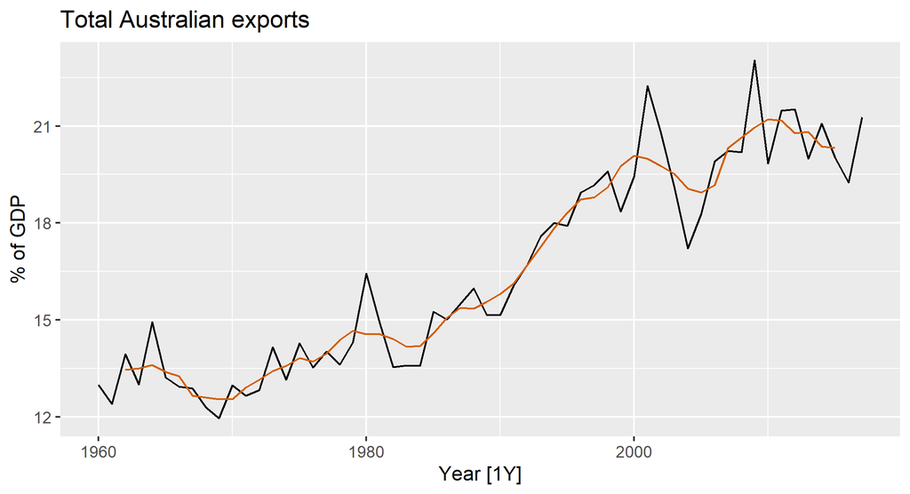

## 이동평균의 복합 적용

- **짝수 차수(m even)** 이동평균은 대칭성이 깨지기 쉬우므로,  
  짝수 차수 이동평균 뒤에 또 다른 이동평균을 적용하여 **중앙 대칭성**을 복원할 수 있다.
- 예:
  - 4-MA를 먼저 적용하고,
  - 그 결과에 2-MA를 적용 → “2×4-MA (centred 4-MA)”
  - 이 조합은 **가중치 이동평균** 형태를 띈다.
- 예시 공식 (예: 2×4-MA):  
  \[ \hat{T}_t = \frac{1}{8} y_{t-2} + \frac{1}{4} y_{t-1} + \frac{1}{4} y_t + \frac{1}{4} y_{t+1} + \frac{1}{8} y_{t+2} \]
- 일반적으로 **홀수 차수 MA** 뒤에 또 홀수 차수 MA,  
  짝수 차수 MA 뒤에 또 짝수 차수 MA를 적용하는 방식이 자주 쓰인다.

## 이동평균의 복합 적용

```r
beer <- aus_production |>
  filter(year(Quarter) >= 1992) |>
  select(Quarter, Beer)
beer_ma <- beer |>
  mutate(
    `4-MA` = slider::slide_dbl(Beer, mean,
                .before = 1, .after = 2, .complete = TRUE),
    `2x4-MA` = slider::slide_dbl(`4-MA`, mean,
                .before = 1, .after = 0, .complete = TRUE)
  )
beer_ma
```

```
## # A tsibble: 74 x 4 [1Q]
##    Quarter  Beer `4-MA` `2x4-MA`
##      <qtr> <dbl>  <dbl>    <dbl>
##  1 1992 Q1   443    NA       NA
##  2 1992 Q2   410   451.      NA
##  3 1992 Q3   420   449.     450
##  4 1992 Q4   532   452.     450.
##  5 1993 Q1   433   449      450.
##  6 1993 Q2   421   444      446.
##  7 1993 Q3   410   448      446
##  8 1993 Q4   512   438      443
##  9 1994 Q1   449   441.     440.
## 10 1994 Q2   381   446      444.
## # ℹ 64 more rows
```

## 계절 자료에서 추세-순환 추정

- 계절성을 가진 시계열에서는 **centred 이동평균** (예: 2×m-MA) 이 계절 효과를 제거할 수 있는 좋은 선택이 된다.
- 예:
  - 월별 자료에 연간 계절성 있을 경우 → 2×12-MA 적용
  - 일별 자료에 주간 계절성 있을 경우 → 7-MA 적용
- 규칙:
  - 계절 주기가 짝수이면 → 2×m-MA
  - 계절 주기가 홀수이면 → m-MA  
    이렇게 하면 추세-순환만 남고 계절 효과는 거의 제거된다.

## 예: 미국 소매업 고용에의 적용

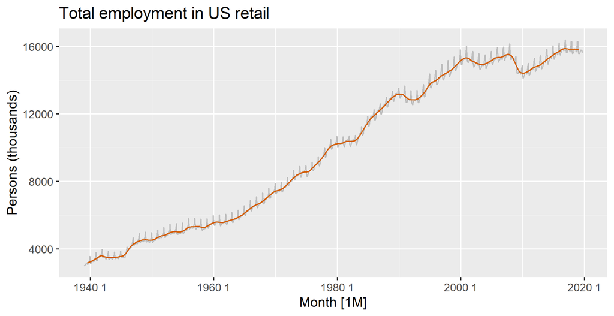

```r
us_retail_employment_ma <- us_retail_employment |>
  mutate(
    `12-MA` = slider::slide_dbl(Employed, mean,
                .before = 5, .after = 6, .complete = TRUE),
    `2x12-MA` = slider::slide_dbl(`12-MA`, mean,
                .before = 1, .after = 0, .complete = TRUE)
  )
us_retail_employment_ma |>
  autoplot(Employed, colour = "gray") +
  geom_line(aes(y = `2x12-MA`), colour = "#D55E00") +
  labs(y = "Persons (thousands)",
       title = "Total employment in US retail")
```

## 예: 미국 소매업 고용에의 적용

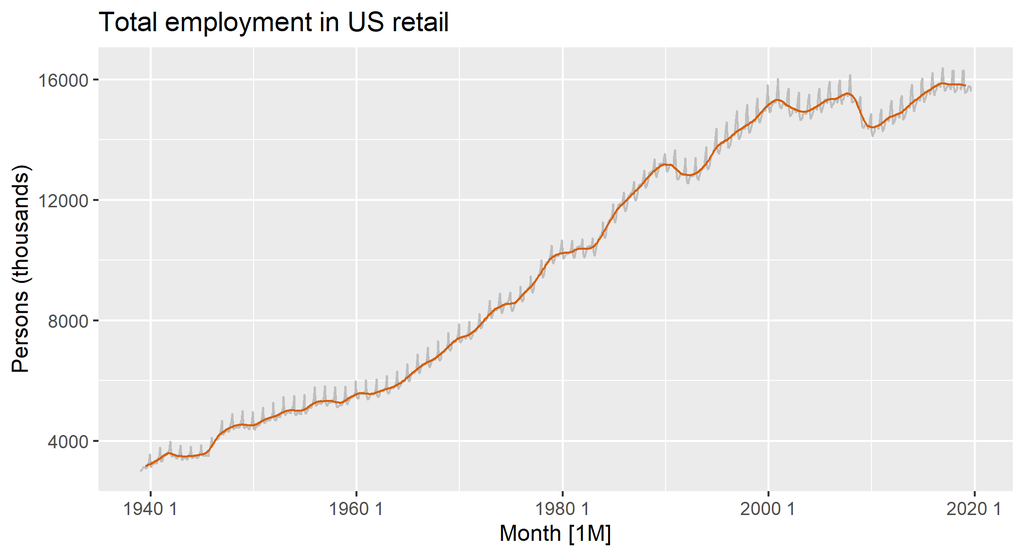

## 가중 이동평균 (Weighted Moving Averages)

- 복합 이동평균은 **가중치 형태의 이동평균**으로 해석할 수 있다:  
  \[ \hat{T}_t = \sum_{j=-k}^{k} a_j \, y_{t+j}, \quad \sum a_j = 1, \; a_{j} = a_{-j} \]
- 단순 \(m\)-MA는 모든 \(a_j = 1/m\) 인 특수한 경우이다.
- 가중치 MA의 장점:
  - 점진적으로 가중치를 부여 → 갑자기 자료가 빠져나가거나 새로 들어오는 변화 완화
  - 더 부드러운 추세곡선 산출 가능

## 요약 정리

- 이동평균은 시계열의 잡음을 제거하고 부드러운 추세-순환 흐름을 제공
- 홀수 차수 MA는 대칭성이 자연스럽지만, 짝수 차수 MA는 대칭성을 위해 복합 MA가 필요
- 계절성이 있는 자료에서는 centred MA (예: 2×m-MA) 가 효과적
- 복합 MA는 가중 이동평균으로 해석 가능하며, 부드러운 곡선 산출에 유리하다

## 고전적 분해법 (Classical Decomposition)

## 개요

- 고전적 분해법은 1920년대에 시작된 비교적 간단한 분해 절차
- 시간 주기 \(m\) (예: 분기 \(m=4\), 월별 \(m=12\), 주간 \(m=7\))을 기준으로
  - **가법 분해(additive decomposition)**
  - **승법 분해(multiplicative decomposition)**  
    두 형태로 나뉜다
- 가정: 계절성 구성요소가 매년 동일하게 반복됨 (변화 없음)  
  승법 분해의 경우 계절 지수(seasonal indices)라는 표현도 사용됨

## 가법 분해 (Additive Decomposition)

1. **추세-순환(Trend-cycle) 추정** \(\hat{T}_t\)
   - \(m\)이 짝수이면 → \(2 \times m\) 중심 이동평균 사용
   - \(m\)이 홀수이면 → \(m\)-차 이동평균 사용
2. **분산 제거 (detrending)**  
   \[ y_t - \hat{T}_t \]
3. **계절성 구성요소** \(\hat{S}_t\) 추정
   - 특정 계절(예: 3월)에 속한 모든 \(y_t - \hat{T}_t\) 값들의 평균
   - 그 값을 모두 연결하고, 매년 반복하도록 확장
   - 계절성 값들의 합이 0이 되도록 보정

## 가법 분해 (Additive Decomposition)

1. **잔차 구성요소** \(\hat{R}_t\) 계산  
   \[ \hat{R}_t = y_t - \hat{T}_t - \hat{S}_t \]

```r
us_retail_employment |>
  model(
    classical_decomposition(Employed, type = "additive")
  ) |>
  components() |>
  autoplot() +
  labs(title = "Classical additive decomposition of total
                  US retail employment")
```

## 가법 분해 (Additive Decomposition)

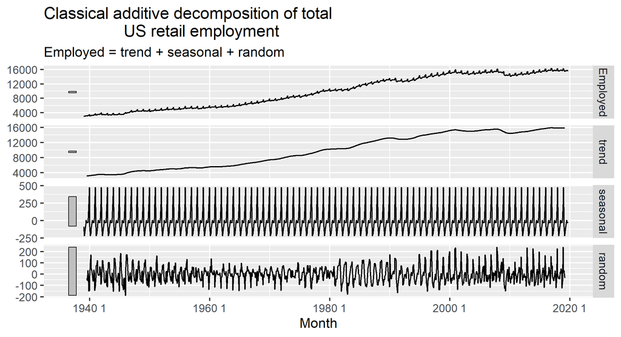

## 승법 분해 (Multiplicative Decomposition)

- 방식은 가법 분해와 유사하나, **빼기 대신 나누기**를 사용
- 절차:
  1. 추세-순환 \(\hat{T}_t\) 추정 (짝수 \(m\)이면 \(2m\)-MA, 홀수이면 \(m\)-MA)
  2. 분산 제거 (detrending):  
     \[ \frac{y_t}{\hat{T}_t} \]
  3. 계절 지수 \(\hat{S}_t\) 추정
     - 특정 계절의 모든 \(y_t / \hat{T}_t\) 값 평균
     - 계절 지수들이 모여 연간 반복 패턴을 구성
     - 지수들의 합이 \(m\) 이 되도록 보정

## 승법 분해 (Multiplicative Decomposition)

- 절차: 4. 잔차 구성요소 \(\hat{R}_t\) 계산:  
  \[ \hat{R}_t = \frac{y_t}{\hat{T}_t \, \hat{S}_t} \]

## 고전적 분해법의 제약 및 단점

- **초기 및 말단 관측값에 대한** \(\hat{T}_t\) 추정 불가  
  → 예: \(m=12\)이면 처음 6개, 마지막 6개 관측치는 추세-순환과 잔차를 계산할 수 없음
- **급격한 상승/하락을 과도하게 평활화(over-smoothing)** 하는 경향  
  → 변동이 빠른 구간을 정확히 반영하기 어려움
- **계절성의 변화 반영 불가능**  
  → 계절 패턴이 시간이 흐르며 변화하는 경우 (예: 전기 수요 패턴 변화) 잘 반영하지 못함
- **이상치(outlier)에 취약**  
  → 특정 기간에 극단치가 있으면 분해 왜곡 가능

## 통계기관에서 사용하는 방법

## 개요

- 미국 인구조사국(US Census Bureau), 한국 통계청 등 공공 통계기관은 많은 경제·사회 시계열을 계절 조정하기 위해 자체적인 **분해 방법** 을 개발해 사용한다.
- 이들 기관은 주로 **X-11 방법** 또는 **SEATS 방법**, 또는 이 둘의 조합을 변형한 방식을 사용한다.
- 이 방법들은 **월별·분기별 시계열**을 위해 설계되었으며, 일별, 시(時)별, 주(週)별 계절성 추정에는 적용되지 않는 경우가 많다.
- R에서 이들 방법을 사용하려면 `seasonal` 패키지가 필요하다.

## X-11 방법

- X-11은 미국 인구조사국에서 시작되었고, 이후 캐나다 통계청에서도 발전되고, 현재 한국은행 및 통계청에도 이를 계량한 방법이 사용되고 있음
- 고전 분해법(classical decomposition)에 여러 보완 단계와 기능을 추가한 방식이다.
- 주요 특징:
  - 추세-순환(trend-cycle) 추정치를 **말단 관측치까지 모두 구함**
  - 계절성 구성요소가 **시간에 따라 서서히 변하도록 허용**
  - 영업일 수 변동(trading-day effect), 휴일 효과(holiday effects), 알려진 예측 변수 효과 처리 가능
  - **가법/승법 모두 가능**
  - 자동 처리 기능이 강하고, 이상치(outliers)나 수준 변화(level shifts)에 강건한 편

## X-11 방법 예제

```r
x11_dcmp <- us_retail_employment |>
  model(x11 = X_13ARIMA_SEATS(Employed ~ x11())) |>
  components()
autoplot(x11_dcmp) +
  labs(title =
    "Decomposition of total US retail employment using X-11")
```

[output not shown]

## X-11 방법 예제

```r
x11_dcmp |>
  ggplot(aes(x = Month)) +
  geom_line(aes(y = Employed, colour = "Data")) +
  geom_line(aes(y = season_adjust,
                colour = "Seasonally Adjusted")) +
  geom_line(aes(y = trend, colour = "Trend")) +
  labs(y = "Persons (thousands)",
       title = "Total employment in US retail") +
  scale_colour_manual(
    values = c("gray", "#0072B2", "#D55E00"),
    breaks = c("Data", "Seasonally Adjusted", "Trend")
  )
```

[output not shown]

```r
x11_dcmp |>
 gg_subseries(seasonal)
```

[output not shown]

## SEATS

- SEATS는 “Seasonal Extraction in ARIMA Time Series”의 약자이며, 스페인 중앙은행(Bank of Spain)에서 개발됨
- ARIMA 모형을 기반으로 계절성·추세를 분리하는 방식
- `X_13ARIMA_SEATS()` 함수는 X-11과 SEATS를 다양한 옵션과 조합으로 다룰 수 있도록 구현됨

```r
seats_dcmp <- us_retail_employment |>
  model(seats = X_13ARIMA_SEATS(Employed ~ seats())) |>
  components()
autoplot(seats_dcmp) +
  labs(title =
    "Decomposition of total US retail employment using SEATS")
```

[output not shown]

## STL 분해 (STL Decomposition)

## 개요

- **STL** = *Seasonal and Trend decomposition using Loess*
  - Loess는 비선형 관계를 매끄럽게 추정하는 기법
  - Cleveland 등(1990) 제안, 이후 복수 계절성 확장됨
- STL의 장점:
  - 월별/분기별 뿐 아니라 **모든 형태의 계절성** 처리 가능
  - 계절성 성분이 **시간에 따라 변화**하도록 허용
  - 추세-순환 정도(smoothness) 조정 가능
  - 이상치(outlier)에 대한 **로버스트(강건) 분해** 옵션 제공
- 단점:
  - 달력 효과(trading day), 휴일 효과(calendar variation)를 자동 처리하지 않음
  - 기본적으로 **가법 분해**만 제공
    - 승법 분해는 로그 변환 후 역변환 또는 Box–Cox 변환을 통해 구현 가능

## STL 분해 적용 및 파라미터 선택

- 주된 조정 변수 두 가지:
  1. **trend(window = ?)**: 추세-순환 성분의 유연성 제어
  2. **season(window = ?)**: 계절 성분의 변화 허용 정도 조절
- **파라미터 제약/관례**:
  - trend, season 모두 **홀수 값** 사용
  - season(window = “periodic”) 설정하면 **고정된 계절성** 강제
  - 기본 설정 예 (단일 계절성):
    - season window = 11
    - 월별 데이터의 경우 trend window 기본값 = 21
- 자동 설정은 일반적으로 합리적 균형을 제공하나,  
  특정 시계열에서는 조정이 필요할 수 있음  
  → 예: 기본 trend window가 너무 강직하여 이상 신호가 잔차에 일부 포함되는 경우